## Waste Water Transmission Network Modelling (High Dimensional Machine Learning Models)

```r
WWT.modelling <- WWT.modelling[c("condition_overall_score_label", setdiff(names(WWT.modelling), "condition_overall_score_label"))]
```

### Creating Training and Testing Datasets

The first thing to do would be to separate the WWT data set into CCTV positive and CCTV negative and then further remove variables that are not going to inform our predictive models.

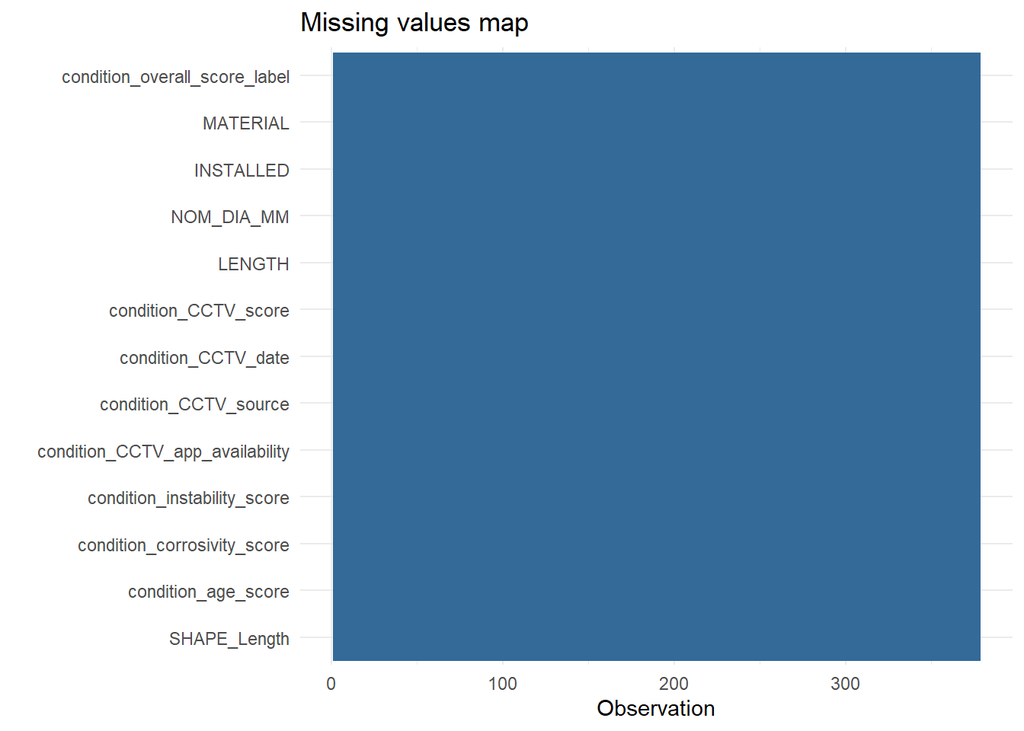

```r
WWT.yes <- WWT.modelling %>% filter(condition_CCTV_app_availability == "yes")
WWT.no <- WWT.modelling %>% filter(condition_CCTV_app_availability == "no")
missing_plot(WWT.yes)
```

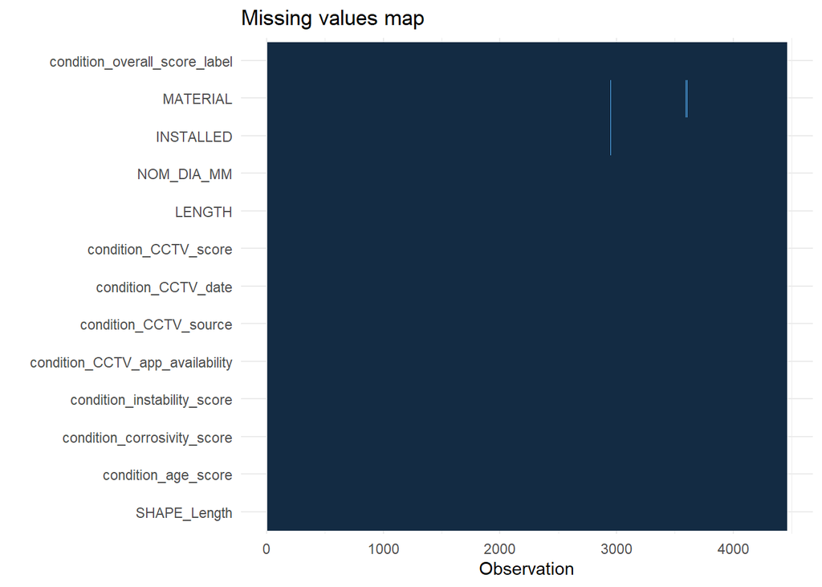

```r
missing_plot(WWT.no)
```

```r
WWT.yes <- WWT.yes[, -9]
WWT.no <- WWT.no[, -9]
```

Unfortunately, when we do this split, the high cctv availability pipes have no pipes with a condition of 5. This is going to be probablmatic, as cctv availablity pipes are going to be our training data. This means that our model will have no knowledge on how to predict level 5 condition pipes.

We need to maintain a distribution of our condition that is consistent with our population dataset.

```r
summary(WWT.modelling$condition_overall_score_label)
```

```
##    1    2    3    4    5
##  842 2362 1279  305   50
```

```r
summary(WWT.yes$condition_overall_score_label)
```

```
##   1   2   3   4   5
##  51 159 137  31   0
```

```r
summary(WWT.no$condition_overall_score_label)
```

```
##    1    2    3    4    5
##  791 2203 1142  274   50
```

I think the only statistically sound way to fix this is to migrate some low confidence data to the high confidence data (map some pipes from no cctv availability to yes cctv availability)

```r
set.seed(123)
rows_to_move <- which(WWT.no$condition_overall_score_label == "5")
num_to_select <- min(10, length(rows_to_move))
selected_rows <- sample(rows_to_move, num_to_select)

WWT.yes <- WWT.yes %>% rbind(WWT.no[selected_rows, ])
WWT.no <- WWT.no[-selected_rows,]


summary(WWT.yes$condition_overall_score_label)
```

```
##   1   2   3   4   5
##  51 159 137  31  10
```

```r
summary(WWT.no$condition_overall_score_label)
```

```
##    1    2    3    4    5
##  791 2203 1142  274   40
```

```r
set.seed(749)
sample.index <- sample(1:nrow(WWT.yes), size = 0.8 * nrow(WWT.yes))
WWT.yes.train <- WWT.yes[sample.index, ]
WWT.yes.test <- WWT.yes[-sample.index, ]
```

### Decision Tree

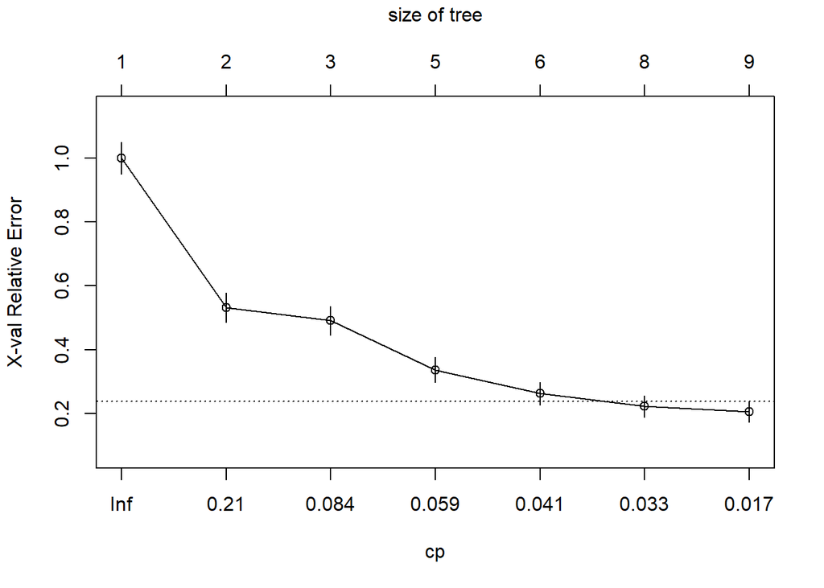

```r
condition.tree1 <- rpart(condition_overall_score_label~., data = WWT.yes.train)
plotcp(condition.tree1)
```

```r
predict1 <- predict(condition.tree1, WWT.yes.test, type = "class")
confMatrix1 <- table(Actual = WWT.yes.test$condition_overall_score_label, Predicted = predict1)
confMatrix1
```

```
##       Predicted
## Actual  1  2  3  4  5
##      1 17  1  0  0  0
##      2  0 24  0  0  0
##      3  0  2 26  0  2
##      4  0  0  0  2  2
##      5  0  0  0  0  2
```

```r
sum(diag(confMatrix1)) / nrow(WWT.yes.test)
```

```
## [1] 0.9102564
```

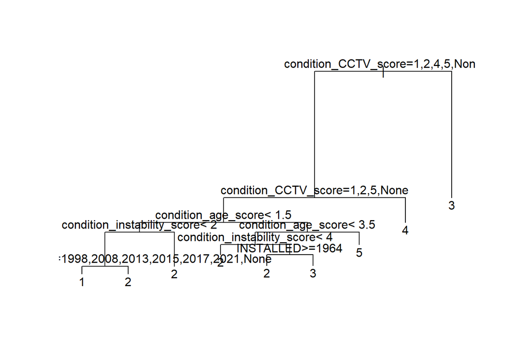

```r
plot(condition.tree1, margin = 0.02)
text(condition.tree1, pretty = 2)
```

```r
printcp(condition.tree1)
```

```
##
## Classification tree:
## rpart(formula = condition_overall_score_label ~ ., data = WWT.yes.train)
##
## Variables actually used in tree construction:
## [1] condition_age_score         condition_CCTV_date
## [3] condition_CCTV_score        condition_instability_score
## [5] INSTALLED
##
## Root node error: 175/310 = 0.56452
##
## n= 310
##
##         CP nsplit rel error  xerror     xstd
## 1 0.468571      0   1.00000 1.00000 0.049885
## 2 0.091429      1   0.53143 0.53143 0.046105
## 3 0.077143      2   0.44000 0.49143 0.045046
## 4 0.045714      4   0.28571 0.33714 0.039495
## 5 0.037143      5   0.24000 0.26286 0.035765
## 6 0.028571      7   0.16571 0.22286 0.033366
## 7 0.010000      8   0.13714 0.20571 0.032234
```

Pruned this tree to a cp of 0.028571

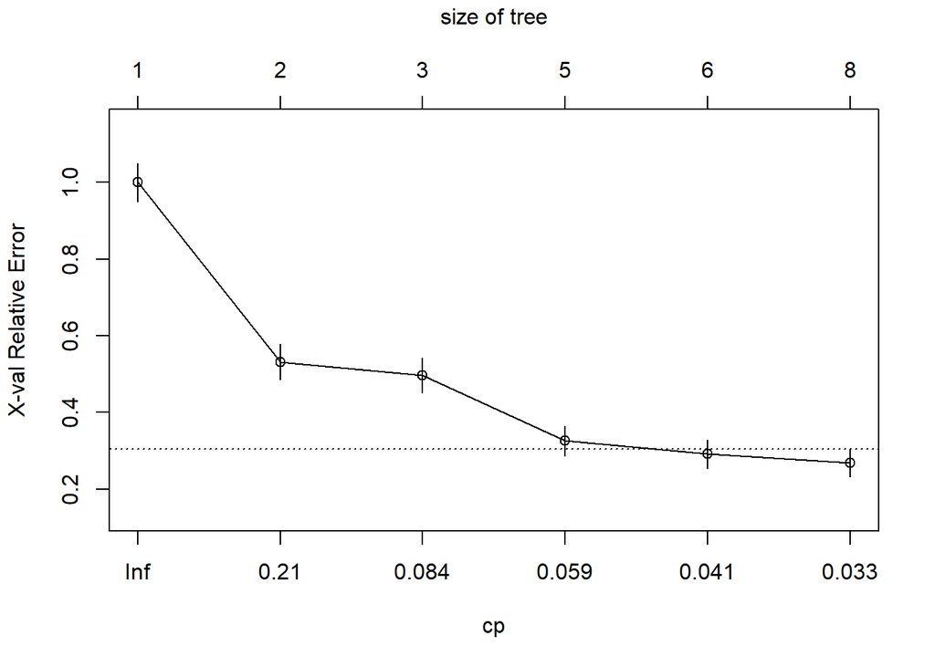

```r
condition.tree2 <- rpart(condition_overall_score_label~., data = WWT.yes.train, cp =0.028751)
plotcp(condition.tree2)
```

```r
predict2 <- predict(condition.tree2, WWT.yes.test, type = "class")
confMatrix2 <- table(Actual = WWT.yes.test$condition_overall_score_label, Predicted = predict2)
confMatrix2
```

```
##       Predicted
## Actual  1  2  3  4  5
##      1 17  1  0  0  0
##      2  0 24  0  0  0
##      3  0  2 26  0  2
##      4  0  0  0  2  2
##      5  0  0  0  0  2
```

```r
sum(diag(confMatrix2)) / nrow(WWT.yes.test)
```

```
## [1] 0.9102564
```

[figure not shown]

```r
plot(condition.tree2)
```

#### Prediction on low confidence dataset

```r
predict3 <- predict(condition.tree2, WWT.no, type = "class")
confMatrix3 <- table(Actual = WWT.no$condition_overall_score_label, Predicted = predict3)
confMatrix3
```

```
##       Predicted
## Actual    1    2    3    4    5
##      1  733   58    0    0    0
##      2  216 1972    9    0    6
##      3    0  128  893    0  121
##      4    0    0   74   67  133
##      5    0    6    1    0   33
```

```r
sum(diag(confMatrix3)) / nrow(WWT.no)
```

```
## [1] 0.8310112
```

### Random Forest

```r
rf_model <- ranger(condition_overall_score_label ~ ., data = WWT.yes.train, trees = 10000, mtry = 5)
predict4 <- predict(rf_model, WWT.yes.test)$predictions
confMatrix4 <- table(Actual = WWT.yes.test$condition_overall_score_label, Predicted = predict4)
confMatrix4
```

```
##       Predicted
## Actual  1  2  3  4  5
##      1 17  1  0  0  0
##      2  0 24  0  0  0
##      3  0  0 30  0  0
##      4  0  0  0  4  0
##      5  0  0  0  0  2
```

```r
sum(diag(confMatrix4)) / nrow(WWT.yes.test)
```

```
## [1] 0.9871795
```

#### Predictions on actual model

```r
predict5 <- predict(rf_model, WWT.no)$predictions
confMatrix5 <- table(Actual = WWT.no$condition_overall_score_label, Predicted = predict5)
confMatrix5
```

```
##       Predicted
## Actual    1    2    3    4    5
##      1  641  111    0    2   37
##      2   16 1956    4  100  127
##      3    0   49  915  113   65
##      4    1    3   57  122   91
##      5    0    0    0    2   38
```

```r
sum(diag(confMatrix5)) / nrow(WWT.no)
```

```
## [1] 0.8251685
```

### Gradient Boosting Model

```r
# Convert data frames to matricies and make data and label sets
library(gbm)


WWT.yes.train.matrix <- model.matrix(~. - 1, WWT.yes.train[, -1])
WWT.yes.train.label <- as.integer(WWT.yes.train$condition_overall_score_label) - 1

WWT.yes.test.matrix <- model.matrix(~. -1 , WWT.yes.test[,-1])
WWT.yes.test.label <- as.integer(WWT.yes.test$condition_overall_score_label) -1

WWT.no <- na.omit(WWT.no)
WWT.no.matrix <- model.matrix(~. -1 , WWT.no[,-1])
WWT.no.label <- as.integer(WWT.no$condition_overall_score_label) -1
```

```r
boosted.conditiontree1 <- xgboost(data = WWT.yes.train.matrix, label = WWT.yes.train.label, max_depth = 10, eta = 1, nthreads = 2, nrounds = 50, num_class = 6, objective = "multi:softmax", verbose = 1 )
```

```
## [14:33:24] WARNING: src/learner.cc:767:
## Parameters: { "nthreads" } are not used.
##
```

```r
xgb.plot.tree(model = boosted.conditiontree1)
```

[interactive chart not shown]

```r
pred6 <- predict(boosted.conditiontree1, WWT.yes.test.matrix)
confMatrix6 <- table(Actual = WWT.yes.test.label,
      Predicted = pred6)
confMatrix6
```

```
##       Predicted
## Actual  0  1  2  3  4
##      0 17  1  0  0  0
##      1  0 24  0  0  0
##      2  0  0 30  0  0
##      3  0  0  0  4  0
##      4  0  0  0  0  2
```

```r
sum(diag(confMatrix6)) / nrow(WWT.yes.test.matrix)
```

```
## [1] 0.9871795
```

```r
pred7 <- predict(boosted.conditiontree1, WWT.no.matrix)
confMatrix7 <- table(Actual = WWT.no.label,
      Predicted = pred7)
confMatrix7
```

```
##       Predicted
## Actual    0    1    2    3    4
##      0  709   78    0    0    0
##      1    0 2172   17    3    7
##      2    0   58 1022   31   20
##      3    6    2   17  161   88
##      4    0    0    2    5   33
```

```r
sum(diag(confMatrix7)) / length(WWT.no.label)
```

```
## [1] 0.924622
```

## Wastewater Transmission Network Modelling on CCTV Condition rather than overall condition (High Dimensional Machine Learning Models)

Dropping overall condition as this is no longer relevant to the modelling we are trying to do

```r
WWT.modelling <- WWT.modelling %>% dplyr::select(-condition_overall_score_label)
```

### Creating Training and Testing Datasets

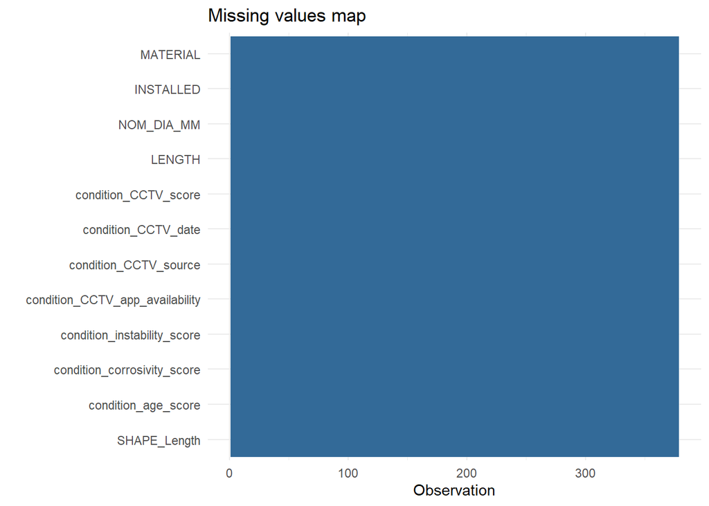

```r
WWT.yes <- WWT.modelling %>% filter(condition_CCTV_app_availability == "yes")
WWT.no <- WWT.modelling %>% filter(condition_CCTV_app_availability == "no")
missing_plot(WWT.yes)
```

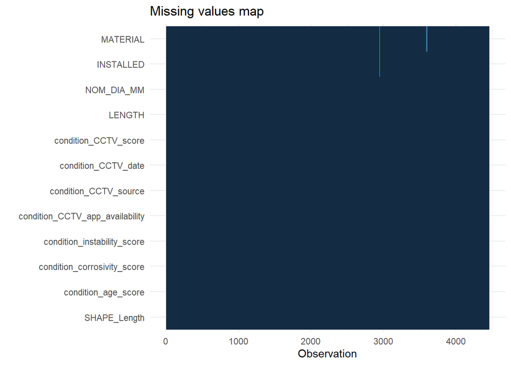

```r
missing_plot(WWT.no)
```

```r
WWT.yes <- WWT.yes %>% dplyr::select(-condition_CCTV_app_availability)
WWT.no <- WWT.no %>% dplyr::select(-condition_CCTV_app_availability)
```

Unfortunately, when we do this split, the high cctv availability pipes have no pipes with a condition of 5. This is going to be probablmatic, as cctv availablity pipes are going to be our training data. This means that our model will have no knowledge on how to predict level 5 condition pipes.

We need to maintain a distribution of our condition that is consistent with our population dataset

```r
summary(WWT.modelling$condition_CCTV_score)
```

```
##    1    2    3    4    5 None
##  403 1632  911   85   11 1796
```

```r
summary(WWT.yes$condition_CCTV_score)
```

```
##    1    2    3    4    5 None
##   41  135  112   18    0   72
```

```r
summary(WWT.no$condition_CCTV_score)
```

```
##    1    2    3    4    5 None
##  362 1497  799   67   11 1724
```

I think the only statistically sound way to fix this is to migrate some low confidence data to the high confidence data (map some pipes from no cctv availability to yes cctv availability)

```r
set.seed(123)
rows_to_move <- which(WWT.no$condition_CCTV_score== "5")
num_to_select <- min(5, length(rows_to_move))
selected_rows <- sample(rows_to_move, num_to_select)

WWT.yes <- WWT.yes %>% rbind(WWT.no[selected_rows, ])
WWT.no <- WWT.no[-selected_rows,]


summary(WWT.yes$condition_CCTV_score)
```

```
##    1    2    3    4    5 None
##   41  135  112   18    5   72
```

```r
summary(WWT.no$condition_CCTV_score)
```

```
##    1    2    3    4    5 None
##  362 1497  799   67    6 1724
```

We are also going to have to drop the “None” category as we are trying to predict the CCTV condition of the pipe whether or not there is cctv availability or a score has been previously taken, so this will be entirely removed from our predictions

```r
WWT.yes <- WWT.yes %>% filter(condition_CCTV_score != "None")
WWT.no <- WWT.no %>% filter(condition_CCTV_score != "None")
```

Make some training and testng datasets

```r
set.seed(749)
sample.index <- sample(1:nrow(WWT.yes), size = 0.8 * nrow(WWT.yes))
WWT.yes.train <- WWT.yes[sample.index, ]
WWT.yes.test <- WWT.yes[-sample.index, ]
```

### Decision Tree

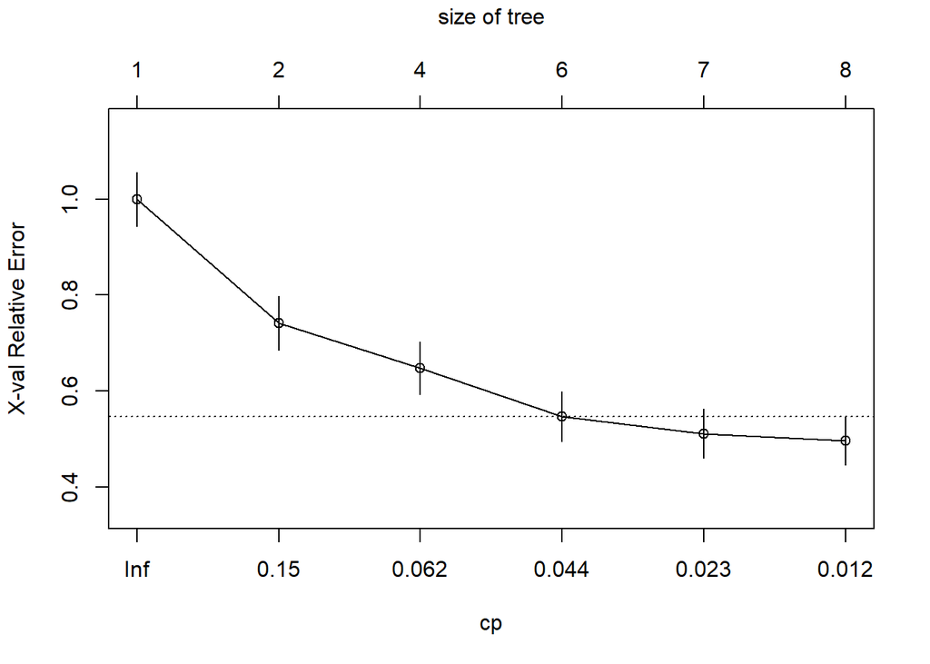

```r
condition.tree1 <- rpart(condition_CCTV_score~., data = WWT.yes.train)
plotcp(condition.tree1)
```

```r
predict1 <- predict(condition.tree1, WWT.yes.test, type = "class")
confMatrix1 <- table(Actual = WWT.yes.test$condition_CCTV_score, Predicted = predict1)
confMatrix1
```

```
##       Predicted
## Actual  1  2  3  4  5 None
##   1     6  1  0  0  0    0
##   2     1 23  2  0  0    0
##   3     0  7 18  2  0    0
##   4     0  0  0  3  0    0
##   5     0  0  0  0  0    0
##   None  0  0  0  0  0    0
```

```r
sum(diag(confMatrix1)) / nrow(WWT.yes.test)
```

```
## [1] 0.7936508
```

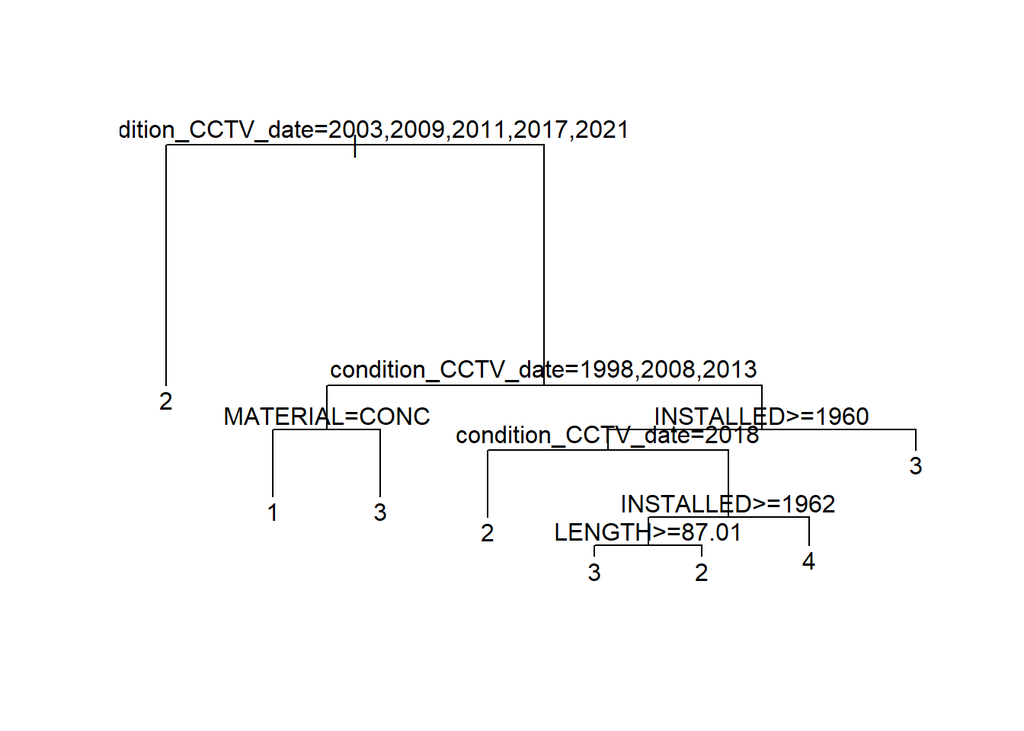

```r
plot(condition.tree1, margin = 0.02)
text(condition.tree1, pretty = 2)
```

```r
printcp(condition.tree1)
```

```
##
## Classification tree:
## rpart(formula = condition_CCTV_score ~ ., data = WWT.yes.train)
##
## Variables actually used in tree construction:
## [1] condition_CCTV_date INSTALLED           LENGTH
## [4] MATERIAL
##
## Root node error: 139/248 = 0.56048
##
## n= 248
##
##         CP nsplit rel error  xerror     xstd
## 1 0.309353      0   1.00000 1.00000 0.056232
## 2 0.071942      1   0.69065 0.74101 0.055829
## 3 0.053957      3   0.54676 0.64748 0.054476
## 4 0.035971      5   0.43885 0.54676 0.052231
## 5 0.014388      6   0.40288 0.51079 0.051212
## 6 0.010000      7   0.38849 0.49640 0.050770
```

#### Prediction on low confidence dataset

```r
predict2 <- predict(condition.tree1, WWT.no, type = "class")
confMatrix2 <- table(Actual = WWT.no$condition_CCTV_score, Predicted = predict2)
confMatrix2
```

```
##       Predicted
## Actual   1   2   3   4   5 None
##   1     99 189  72   2   0    0
##   2    127 954 350  66   0    0
##   3     85 438 259  17   0    0
##   4      8  32  24   3   0    0
##   5      0   2   4   0   0    0
##   None   0   0   0   0   0    0
```

```r
sum(diag(confMatrix2)) / nrow(WWT.no)
```

```
## [1] 0.4815086
```

### Random Forest

```r
rf_model <- ranger(condition_CCTV_score ~ ., data = WWT.yes.train, trees = 10000, mtry = 5)
predict3 <- predict(rf_model, WWT.yes.test)$predictions
confMatrix3 <- table(Actual = WWT.yes.test$condition_CCTV_score, Predicted = predict3)
confMatrix3
```

```
##       Predicted
## Actual  1  2  3  4  5 None
##   1     5  1  1  0  0    0
##   2     0 24  2  0  0    0
##   3     0  3 23  1  0    0
##   4     0  0  0  3  0    0
##   5     0  0  0  0  0    0
##   None  0  0  0  0  0    0
```

```r
sum(diag(confMatrix3)) / nrow(WWT.yes.test)
```

```
## [1] 0.8730159
```

#### Predictions on low confidence dataset

```r
predict4 <- predict(rf_model, WWT.no)$predictions
confMatrix4 <- table(Actual = WWT.no$condition_CCTV_score, Predicted = predict4)
confMatrix4
```

```
##       Predicted
## Actual   1   2   3   4   5 None
##   1    178  85  97   2   0    0
##   2    157 648 668  24   0    0
##   3     54 372 353  20   0    0
##   4      5  25  27   0  10    0
##   5      1   0   0   0   5    0
##   None   0   0   0   0   0    0
```

```r
sum(diag(confMatrix4)) / nrow(WWT.no)
```

```
## [1] 0.4335408
```

### Gradient Boosting Model

```r
# Convert data frames to matricies and make data and label sets
library(gbm)


WWT.yes.train.matrix <- model.matrix(~. - 1, WWT.yes.train[, -1])
WWT.yes.train.label <- as.integer(WWT.yes.train$condition_CCTV_score) - 1

WWT.yes.test.matrix <- model.matrix(~. -1 , WWT.yes.test[,-1])
WWT.yes.test.label <- as.integer(WWT.yes.test$condition_CCTV_score) -1

WWT.no <- na.omit(WWT.no)
WWT.no.matrix <- model.matrix(~. -1 , WWT.no[,-1])
WWT.no.label <- as.integer(WWT.no$condition_CCTV_score) -1
```

```r
boosted.conditiontree1 <- xgboost(data = WWT.yes.train.matrix, label = WWT.yes.train.label, max_depth = 3, min_child_weight = 5, eta = 1, nthreads = 2, nrounds = 20, num_class = 6, objective = "multi:softmax", verbose = 1, lambda = 1 )
```

```
## [14:33:27] WARNING: src/learner.cc:767:
## Parameters: { "nthreads" } are not used.
##
```

```r
xgb.plot.tree(model = boosted.conditiontree1)
```

[interactive chart not shown]

```r
pred5 <- predict(boosted.conditiontree1, WWT.yes.test.matrix)
confMatrix5 <- table(Actual = WWT.yes.test.label,
      Predicted = pred5)
confMatrix5
```

```
##       Predicted
## Actual  0  1  2  3
##      0  7  0  0  0
##      1  0 26  0  0
##      2  0  0 27  0
##      3  0  0  0  3
```

```r
sum(diag(confMatrix5)) / nrow(WWT.yes.test.matrix)
```

```
## [1] 1
```

```r
pred6 <- predict(boosted.conditiontree1, WWT.no.matrix)
confMatrix6 <- table(Actual = WWT.no.label,
      Predicted = pred6)
confMatrix6
```

```
##       Predicted
## Actual    0    1    2    3    4
##      0  362    0    0    0    0
##      1    0 1497    0    0    0
##      2    0    0  799    0    0
##      3    0    0    0   67    0
##      4    0    0    0    1    5
```

```r
sum(diag(confMatrix6)) / length(WWT.no.label)
```

```
## [1] 0.9996338
```

Gradient Boosted Model needs some regularisation in order to be effective for larger data sets

## Wastewater Transmission Network Modelling on CCTV condition (Segmented models)

```r
WWT.modelling <- read_csv("WWT.modelling.csv")
WWT.modelling <- WWT.modelling %>% mutate_if(is.character, as.factor)
```

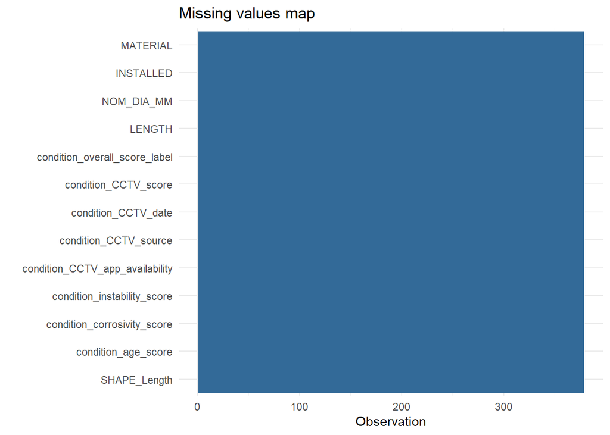

```r
WWT.yes <- WWT.modelling %>% filter(condition_CCTV_app_availability == "yes")
WWT.no <- WWT.modelling %>% filter(condition_CCTV_app_availability == "no")
missing_plot(WWT.yes)
```

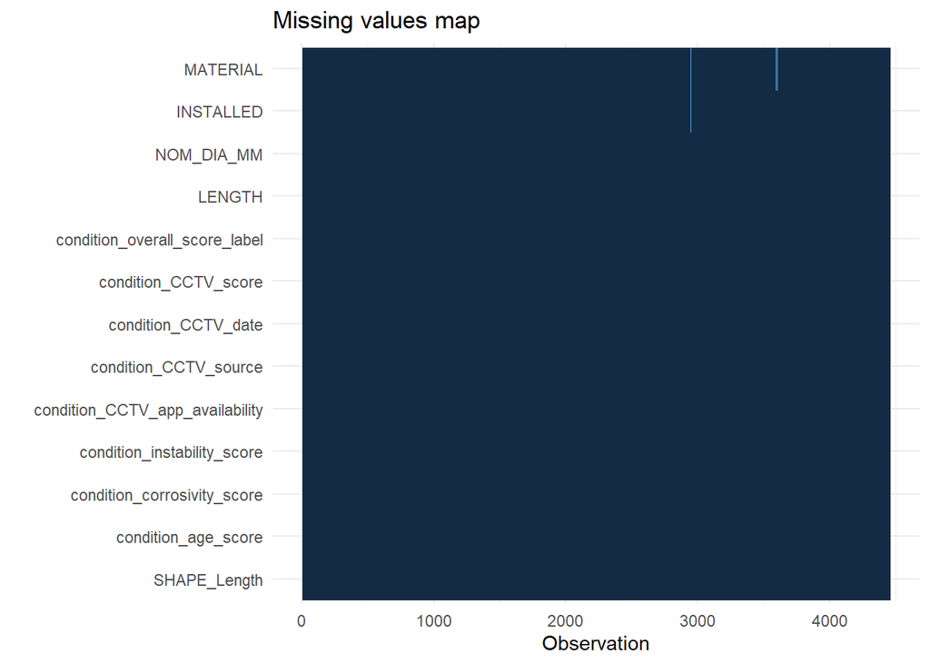

```r
missing_plot(WWT.no)
```

```r
WWT.yes <- WWT.yes %>% dplyr::select(-condition_CCTV_app_availability)
WWT.no <- WWT.no %>% dplyr::select(-condition_CCTV_app_availability)
```

```r
summary(WWT.modelling$condition_CCTV_score)
```

```
##    1    2    3    4    5 None
##  403 1632  911   85   11 1796
```

```r
summary(WWT.yes$condition_CCTV_score)
```

```
##    1    2    3    4    5 None
##   41  135  112   18    0   72
```

```r
summary(WWT.no$condition_CCTV_score)
```

```
##    1    2    3    4    5 None
##  362 1497  799   67   11 1724
```

I think the only statistically sound way to fix this is to migrate some low confidence data to the high confidence data (map some pipes from no cctv availability to yes cctv availability)

```r
set.seed(123)
rows_to_move <- which(WWT.no$condition_CCTV_score== "5")
num_to_select <- min(5, length(rows_to_move))
selected_rows <- sample(rows_to_move, num_to_select)

WWT.yes <- WWT.yes %>% rbind(WWT.no[selected_rows, ])
WWT.no <- WWT.no[-selected_rows,]


summary(WWT.yes$condition_CCTV_score)
```

```
##    1    2    3    4    5 None
##   41  135  112   18    5   72
```

```r
summary(WWT.no$condition_CCTV_score)
```

```
##    1    2    3    4    5 None
##  362 1497  799   67    6 1724
```

We are also going to have to drop the “None” category as we are trying to predict the CCTV condition of the pipe whether or not there is cctv availability or a score has been previously taken, so this will be entirely removed from our predictions

```r
WWT.yes <- WWT.yes %>% filter(condition_CCTV_score != "None")
WWT.no <- WWT.no %>% filter(condition_CCTV_score != "None")
```

Make some training and testng datasets

```r
set.seed(749)
sample.index <- sample(1:nrow(WWT.yes), size = 0.8 * nrow(WWT.yes))
WWT.yes.train <- WWT.yes[sample.index, ]
WWT.yes.test <- WWT.yes[-sample.index, ]
WWT.no.test <- WWT.no[sample(1:nrow(WWT.no), size = 0.1 * nrow(WWT.no)), ]
```

A new function for predictions to speed up this process

```r
predictor1 <- function(model, data){

  prediction <- predict(model, data)$predictions
  confMatrix <- table(Actual = data$condition_CCTV_score, Predicted = prediction)
  print(confMatrix)
  print(sum(diag(confMatrix)) / nrow(data))
}
predictor2 <- function(model, data){

  prediction <- predict(model, data)
  confMatrix <- table(Actual = data$condition_CCTV_score, Predicted = prediction)
  print(confMatrix)
  print(sum(diag(confMatrix)) / nrow(data))
}
predictor3 <- function(model, data){

  prediction <- predict(model, data, type = "class")
  confMatrix <- table(Actual = data$condition_CCTV_score, Predicted = prediction)
  print(confMatrix)
  print(sum(diag(confMatrix)) / nrow(data))
}
```

### Material

Going to fit a multinomal logistic regression model, decision tree model, random forests, and an SVM.

#### Training

Multinomal logistic

```r
library(nnet)
m.logistic <- multinom(condition_CCTV_score ~ MATERIAL, data = WWT.yes.train)
predictor2(m.logistic, WWT.yes.test)
```

```
##       Predicted
## Actual  1  2  3  4  5
##   1     0  6  1  0  0
##   2     0 25  1  0  0
##   3     0 19  8  0  0
##   4     0  3  0  0  0
##   5     0  0  0  0  0
##   None  0  0  0  0  0
## [1] 0.5238095
```

```r
summary(m.logistic)
```

```
## Call:
## multinom(formula = condition_CCTV_score ~ MATERIAL, data = WWT.yes.train)
##
## Coefficients:
##   (Intercept) MATERIALAC MATERIALBRICK MATERIALCI MATERIALCLS MATERIALConc
## 2  -3.9427138    4.63589             0  -5.491136  -11.378255            0
## 3   0.8233588  -16.01644             0  35.765232  -19.784246            0
## 4  -9.2609695  -16.73595             0  -2.995265   -6.368168            0
## 5 -21.9876588  -41.24580             0 -11.091444   46.219574            0
##   MATERIALCONC MATERIALCU MATERIALDI MATERIALELS MATERIALFRP MATERIALGRP
## 2    5.2644819          0          0           0           0           0
## 3   -0.2637428          0          0           0           0           0
## 4    8.4937580          0          0           0           0           0
## 5    5.1915672          0          0           0           0           0
##   MATERIALMS MATERIALPE MATERIALPP MATERIALPVC-U MATERIALSS MATERIALVC
## 2          0          0          0             0          0   3.026306
## 3          0          0          0             0          0   1.122553
## 4          0          0          0             0          0   8.344657
## 5          0          0          0             0          0 -21.061558
##
## Std. Errors:
##   (Intercept)   MATERIALAC MATERIALBRICK   MATERIALCI  MATERIALCLS MATERIALConc
## 2   0.3746088 9.435777e-01  1.559382e-14 6.542119e-15 4.900850e-09 1.346391e-15
## 3   0.1778555 1.449290e-06  0.000000e+00 6.644868e-16 1.286695e-10 0.000000e+00
## 4   0.3004890 2.608737e-11  0.000000e+00 1.154335e-22 3.601106e-09 0.000000e+00
## 5 419.3954720 5.092471e-20  0.000000e+00 8.176801e-23 2.208433e-02 0.000000e+00
##   MATERIALCONC MATERIALCU MATERIALDI MATERIALELS MATERIALFRP MATERIALGRP
## 2    0.4036718        NaN          0           0           0           0
## 3    0.2243663          0          0           0           0           0
## 4    0.3575453          0          0           0           0           0
## 5  419.3733876          0          0           0           0           0
##   MATERIALMS MATERIALPE MATERIALPP MATERIALPVC-U MATERIALSS   MATERIALVC
## 2          0          0          0             0          0 7.002566e-01
## 3          0          0          0             0          0 3.283636e-01
## 4          0          0          0             0          0 5.688844e-01
## 5          0          0          0             0          0 1.485296e-10
##
## Residual Deviance: 510.7615
## AIC: 550.7615
```

Decision Tree Model

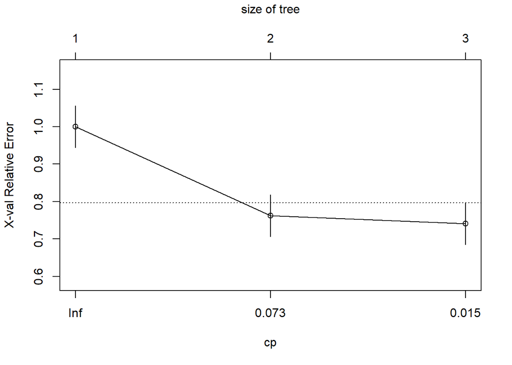

```r
condition.tree <- rpart(condition_CCTV_score~ MATERIAL, data = WWT.yes.train)
plotcp(condition.tree)
```

```r
predictor3(condition.tree, WWT.yes.test)
```

```
##       Predicted
## Actual  1  2  3  4  5 None
##   1     0  7  0  0  0    0
##   2     0 25  1  0  0    0
##   3     0 19  8  0  0    0
##   4     0  3  0  0  0    0
##   5     0  0  0  0  0    0
##   None  0  0  0  0  0    0
## [1] 0.5238095
```

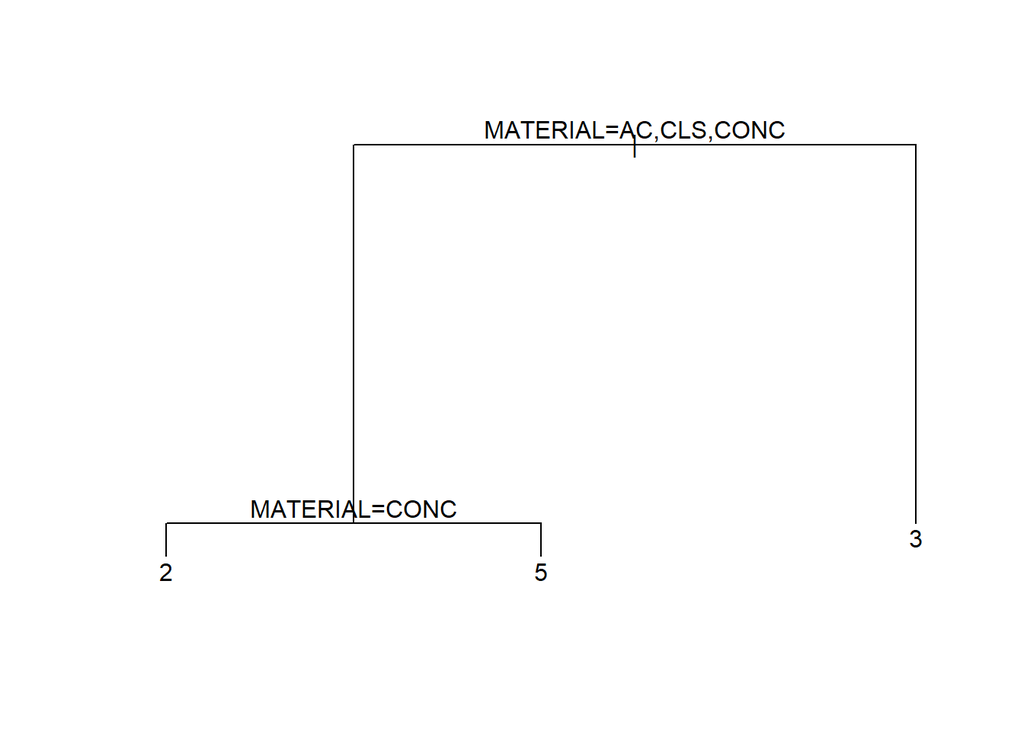

```r
plot(condition.tree, margin = 0.02)
text(condition.tree, pretty = 2)
```

```r
rf_model <- ranger(condition_CCTV_score ~ MATERIAL, data = WWT.yes.train, trees = 10000, mtry = 1)
predictor1(rf_model, WWT.yes.test)
```

```
##       Predicted
## Actual  1  2  3  4  5 None
##   1     0  6  1  0  0    0
##   2     0 25  1  0  0    0
##   3     0 19  8  0  0    0
##   4     0  3  0  0  0    0
##   5     0  0  0  0  0    0
##   None  0  0  0  0  0    0
## [1] 0.5238095
```

SVM

```r
library(e1071)
svm_model <- svm(condition_CCTV_score ~ MATERIAL, data = WWT.yes.train, kernal = "linear", cost = 1, scale = TRUE)
summary(svm_model)
```

```
##
## Call:
## svm(formula = condition_CCTV_score ~ MATERIAL, data = WWT.yes.train,
##     kernal = "linear", cost = 1, scale = TRUE)
##
##
## Parameters:
##    SVM-Type:  C-classification
##  SVM-Kernel:  radial
##        cost:  1
##
## Number of Support Vectors:  180
##
##  ( 63 63 15 34 5 )
##
##
## Number of Classes:  5
##
## Levels:
##  1 2 3 4 5 None
```

```r
predictor2(svm_model, WWT.yes.test)
```

```
##       Predicted
## Actual  1  2  3  4  5 None
##   1     0  7  0  0  0    0
##   2     0 25  1  0  0    0
##   3     0 19  8  0  0    0
##   4     0  3  0  0  0    0
##   5     0  0  0  0  0    0
##   None  0  0  0  0  0    0
## [1] 0.5238095
```

#### Predictions

Going to take a new random sample of the low confidence dataset on every prediction run

```r
# Predictions with the low confidence dataset using the multinomal regression model
set.seed(1)
WWT.no.test <- WWT.no[sample(1:nrow(WWT.no), size = 0.1 * nrow(WWT.no)), ]
predicton1 <- predictor2(m.logistic, WWT.no.test)
```

```
##       Predicted
## Actual   1   2   3   4   5
##   1      0  22  10   0   1
##   2      0 124  12   0   1
##   3      0  85  10   0   2
##   4      0   6   0   0   0
##   5      0   0   0   0   0
##   None   0   0   0   0   0
## [1] 0.4908425
```

```r
# Predictions with the low confidence dataset using the decision tree model
set.seed(2)
WWT.no.test <- WWT.no[sample(1:nrow(WWT.no), size = 0.1 * nrow(WWT.no)), ]
predicton2 <- predictor3(condition.tree, WWT.no.test)
```

```
##       Predicted
## Actual   1   2   3   4   5 None
##   1      0  32   5   0   0    0
##   2      0 137   4   0   6    0
##   3      0  76   7   0   2    0
##   4      0   3   0   0   0    0
##   5      0   0   0   0   1    0
##   None   0   0   0   0   0    0
## [1] 0.5311355
```

```r
# Predictions with the low confidence dataset using the random forest model
set.seed(3)
WWT.no.test <- WWT.no[sample(1:nrow(WWT.no), size = 0.1 * nrow(WWT.no)), ]
predicton3 <- predictor1(rf_model, WWT.no.test)
```

```
##       Predicted
## Actual   1   2   3   4   5 None
##   1      0  23  12   0   0    0
##   2      0 145   4   0   5    0
##   3      0  62   5   0   4    0
##   4      0  11   1   0   0    0
##   5      0   0   0   0   1    0
##   None   0   0   0   0   0    0
## [1] 0.5531136
```

```r
# Predictions with the low confidence dataset using the SVM
set.seed(4)
WWT.no.test <- WWT.no[sample(1:nrow(WWT.no), size = 0.1 * nrow(WWT.no)), ]
predicton4 <- predictor2(svm_model, WWT.no.test)
```

```
##       Predicted
## Actual   1   2   3   4   5 None
##   1      0  33   2   0   0    0
##   2      0 147   4   0   0    0
##   3      0  77   5   0   0    0
##   4      0   5   0   0   0    0
##   5      0   0   0   0   0    0
##   None   0   0   0   0   0    0
## [1] 0.5567766
```

#### Training

```r
library(nnet)
m.logistic <- multinom(condition_CCTV_score ~ MATERIAL, data = WWT.yes.train)
predictor2(m.logistic, WWT.yes.test)
```

```
##       Predicted
## Actual  1  2  3  4  5
##   1     0  6  1  0  0
##   2     0 25  1  0  0
##   3     0 19  8  0  0
##   4     0  3  0  0  0
##   5     0  0  0  0  0
##   None  0  0  0  0  0
## [1] 0.5238095
```

```r
summary(m.logistic)
```

```
## Call:
## multinom(formula = condition_CCTV_score ~ MATERIAL, data = WWT.yes.train)
##
## Coefficients:
##   (Intercept) MATERIALAC MATERIALBRICK MATERIALCI MATERIALCLS MATERIALConc
## 2  -3.9427138    4.63589             0  -5.491136  -11.378255            0
## 3   0.8233588  -16.01644             0  35.765232  -19.784246            0
## 4  -9.2609695  -16.73595             0  -2.995265   -6.368168            0
## 5 -21.9876588  -41.24580             0 -11.091444   46.219574            0
##   MATERIALCONC MATERIALCU MATERIALDI MATERIALELS MATERIALFRP MATERIALGRP
## 2    5.2644819          0          0           0           0           0
## 3   -0.2637428          0          0           0           0           0
## 4    8.4937580          0          0           0           0           0
## 5    5.1915672          0          0           0           0           0
##   MATERIALMS MATERIALPE MATERIALPP MATERIALPVC-U MATERIALSS MATERIALVC
## 2          0          0          0             0          0   3.026306
## 3          0          0          0             0          0   1.122553
## 4          0          0          0             0          0   8.344657
## 5          0          0          0             0          0 -21.061558
##
## Std. Errors:
##   (Intercept)   MATERIALAC MATERIALBRICK   MATERIALCI  MATERIALCLS MATERIALConc
## 2   0.3746088 9.435777e-01  1.559382e-14 6.542119e-15 4.900850e-09 1.346391e-15
## 3   0.1778555 1.449290e-06  0.000000e+00 6.644868e-16 1.286695e-10 0.000000e+00
## 4   0.3004890 2.608737e-11  0.000000e+00 1.154335e-22 3.601106e-09 0.000000e+00
## 5 419.3954720 5.092471e-20  0.000000e+00 8.176801e-23 2.208433e-02 0.000000e+00
##   MATERIALCONC MATERIALCU MATERIALDI MATERIALELS MATERIALFRP MATERIALGRP
## 2    0.4036718        NaN          0           0           0           0
## 3    0.2243663          0          0           0           0           0
## 4    0.3575453          0          0           0           0           0
## 5  419.3733876          0          0           0           0           0
##   MATERIALMS MATERIALPE MATERIALPP MATERIALPVC-U MATERIALSS   MATERIALVC
## 2          0          0          0             0          0 7.002566e-01
## 3          0          0          0             0          0 3.283636e-01
## 4          0          0          0             0          0 5.688844e-01
## 5          0          0          0             0          0 1.485296e-10
##
## Residual Deviance: 510.7615
## AIC: 550.7615
```

Decision Tree Model

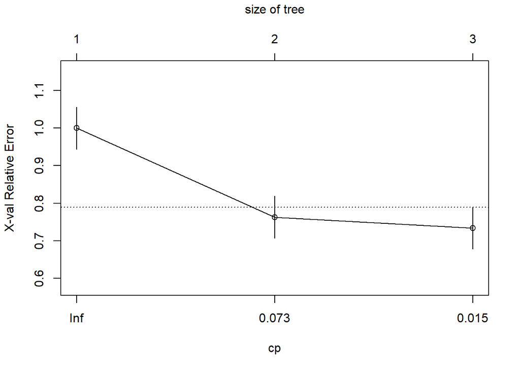

```r
condition.tree <- rpart(condition_CCTV_score~ MATERIAL, data = WWT.yes.train)
plotcp(condition.tree)
```

```r
predictor3(condition.tree, WWT.yes.test)
```

```
##       Predicted
## Actual  1  2  3  4  5 None
##   1     0  7  0  0  0    0
##   2     0 25  1  0  0    0
##   3     0 19  8  0  0    0
##   4     0  3  0  0  0    0
##   5     0  0  0  0  0    0
##   None  0  0  0  0  0    0
## [1] 0.5238095
```

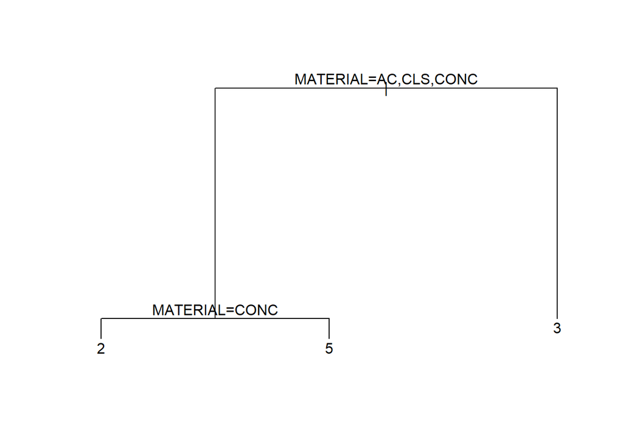

```r
plot(condition.tree, margin = 0.02)
text(condition.tree, pretty = 2)
```

```r
rf_model <- ranger(condition_CCTV_score ~ MATERIAL, data = WWT.yes.train, trees = 10000, mtry = 1)
predictor1(rf_model, WWT.yes.test)
```

```
##       Predicted
## Actual  1  2  3  4  5 None
##   1     0  6  1  0  0    0
##   2     0 25  1  0  0    0
##   3     0 19  8  0  0    0
##   4     0  3  0  0  0    0
##   5     0  0  0  0  0    0
##   None  0  0  0  0  0    0
## [1] 0.5238095
```

SVM

```r
library(e1071)
svm_model <- svm(condition_CCTV_score ~ MATERIAL, data = WWT.yes.train, kernal = "linear", cost = 1, scale = TRUE)
summary(svm_model)
```

```
##
## Call:
## svm(formula = condition_CCTV_score ~ MATERIAL, data = WWT.yes.train,
##     kernal = "linear", cost = 1, scale = TRUE)
##
##
## Parameters:
##    SVM-Type:  C-classification
##  SVM-Kernel:  radial
##        cost:  1
##
## Number of Support Vectors:  180
##
##  ( 63 63 15 34 5 )
##
##
## Number of Classes:  5
##
## Levels:
##  1 2 3 4 5 None
```

```r
predictor2(svm_model, WWT.yes.test)
```

```
##       Predicted
## Actual  1  2  3  4  5 None
##   1     0  7  0  0  0    0
##   2     0 25  1  0  0    0
##   3     0 19  8  0  0    0
##   4     0  3  0  0  0    0
##   5     0  0  0  0  0    0
##   None  0  0  0  0  0    0
## [1] 0.5238095
```

#### Predictions

```r
# Predictions with the low confidence dataset using the multinomal regression model
set.seed(1)
WWT.no.test <- WWT.no[sample(1:nrow(WWT.no), size = 0.1 * nrow(WWT.no)), ]
predicton1 <- predictor2(m.logistic, WWT.no.test)
```

```
##       Predicted
## Actual   1   2   3   4   5
##   1      0  22  10   0   1
##   2      0 124  12   0   1
##   3      0  85  10   0   2
##   4      0   6   0   0   0
##   5      0   0   0   0   0
##   None   0   0   0   0   0
## [1] 0.4908425
```

```r
# Predictions with the low confidence dataset using the decision tree model
set.seed(2)
WWT.no.test <- WWT.no[sample(1:nrow(WWT.no), size = 0.1 * nrow(WWT.no)), ]
predicton2 <- predictor3(condition.tree, WWT.no.test)
```

```
##       Predicted
## Actual   1   2   3   4   5 None
##   1      0  32   5   0   0    0
##   2      0 137   4   0   6    0
##   3      0  76   7   0   2    0
##   4      0   3   0   0   0    0
##   5      0   0   0   0   1    0
##   None   0   0   0   0   0    0
## [1] 0.5311355
```

```r
# Predictions with the low confidence dataset using the random forest model
set.seed(3)
WWT.no.test <- WWT.no[sample(1:nrow(WWT.no), size = 0.1 * nrow(WWT.no)), ]
predicton3 <- predictor1(rf_model, WWT.no.test)
```

```
##       Predicted
## Actual   1   2   3   4   5 None
##   1      0  23  12   0   0    0
##   2      0 145   4   0   5    0
##   3      0  62   5   0   4    0
##   4      0  11   1   0   0    0
##   5      0   0   0   0   1    0
##   None   0   0   0   0   0    0
## [1] 0.5531136
```

```r
# Predictions with the low confidence dataset using the SVM
set.seed(4)
WWT.no.test <- WWT.no[sample(1:nrow(WWT.no), size = 0.1 * nrow(WWT.no)), ]
predicton4 <- predictor2(svm_model, WWT.no.test)
```

```
##       Predicted
## Actual   1   2   3   4   5 None
##   1      0  33   2   0   0    0
##   2      0 147   4   0   0    0
##   3      0  77   5   0   0    0
##   4      0   5   0   0   0    0
##   5      0   0   0   0   0    0
##   None   0   0   0   0   0    0
## [1] 0.5567766
```

### Nominal Diameter

#### Training

Multinomal Logistic Regression

```r
library(nnet)
m.logistic <- multinom(condition_CCTV_score ~ NOM_DIA_MM, data = WWT.yes.train)
predictor2(m.logistic, WWT.yes.test)
```

```
##       Predicted
## Actual  1  2  3  4  5
##   1     0  4  3  0  0
##   2     0 19  7  0  0
##   3     0 10 17  0  0
##   4     0  3  0  0  0
##   5     0  0  0  0  0
##   None  0  0  0  0  0
## [1] 0.5714286
```

```r
summary(m.logistic)
```

```
## Call:
## multinom(formula = condition_CCTV_score ~ NOM_DIA_MM, data = WWT.yes.train)
##
## Coefficients:
##   (Intercept)    NOM_DIA_MM
## 2  0.05663594  0.0019270338
## 3  1.32824841 -0.0008151769
## 4 -4.93926354  0.0054926043
## 5  0.60987611 -0.0056652583
##
## Std. Errors:
##   (Intercept)   NOM_DIA_MM
## 2   0.5018181 0.0008644263
## 3   0.5328261 0.0009803413
## 4   1.0089593 0.0011681657
## 5   0.1770566 0.0013049286
##
## Residual Deviance: 564.6887
## AIC: 580.6887
```

Decision Tree Model

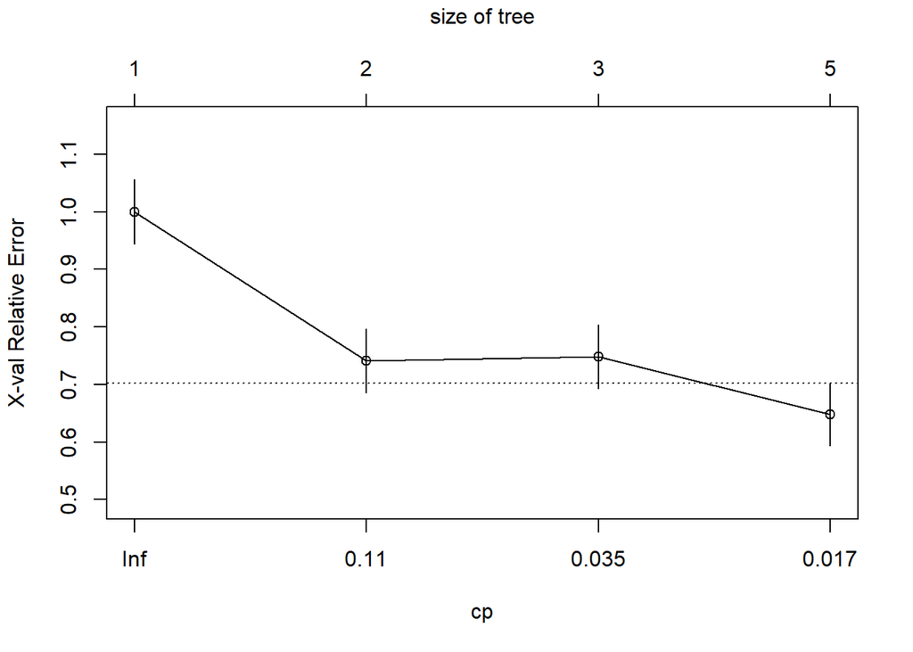

```r
condition.tree <- rpart(condition_CCTV_score~ NOM_DIA_MM, data = WWT.yes.train)
plotcp(condition.tree)
```

```r
predictor3(condition.tree, WWT.yes.test)
```

```
##       Predicted
## Actual  1  2  3  4  5 None
##   1     0  3  4  0  0    0
##   2     0 19  7  0  0    0
##   3     0  4 21  2  0    0
##   4     0  0  0  3  0    0
##   5     0  0  0  0  0    0
##   None  0  0  0  0  0    0
## [1] 0.6825397
```

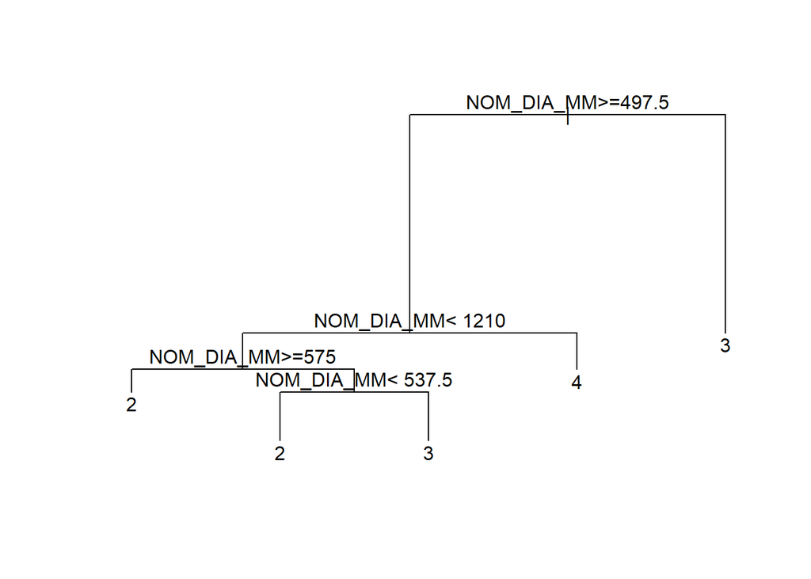

```r
plot(condition.tree, margin = 0.02)
text(condition.tree, pretty = 2)
```

```r
rf_model <- ranger(condition_CCTV_score ~ NOM_DIA_MM, data = WWT.yes.train, trees = 10000, mtry = 1)
predictor1(rf_model, WWT.yes.test)
```

```
##       Predicted
## Actual  1  2  3  4  5 None
##   1     1  3  3  0  0    0
##   2     1 18  6  0  1    0
##   3     0  4 21  2  0    0
##   4     0  0  0  3  0    0
##   5     0  0  0  0  0    0
##   None  0  0  0  0  0    0
## [1] 0.6825397
```

SVM

```r
library(e1071)
svm_model <- svm(condition_CCTV_score ~ NOM_DIA_MM, data = WWT.yes.train, kernal = "linear", cost = 1, scale = TRUE)
summary(svm_model)
```

```
##
## Call:
## svm(formula = condition_CCTV_score ~ NOM_DIA_MM, data = WWT.yes.train,
##     kernal = "linear", cost = 1, scale = TRUE)
##
##
## Parameters:
##    SVM-Type:  C-classification
##  SVM-Kernel:  radial
##        cost:  1
##
## Number of Support Vectors:  183
##
##  ( 64 65 15 34 5 )
##
##
## Number of Classes:  5
##
## Levels:
##  1 2 3 4 5 None
```

```r
predictor2(svm_model, WWT.yes.test)
```

```
##       Predicted
## Actual  1  2  3  4  5 None
##   1     0  3  4  0  0    0
##   2     0 19  7  0  0    0
##   3     0  8 17  2  0    0
##   4     0  0  0  3  0    0
##   5     0  0  0  0  0    0
##   None  0  0  0  0  0    0
## [1] 0.6190476
```

#### Predictions

```r
# Predictions with the low confidence dataset using the multinomal regression model
set.seed(1)
WWT.no.test <- WWT.no[sample(1:nrow(WWT.no), size = 0.1 * nrow(WWT.no)), ]
predicton1 <- predictor2(m.logistic, WWT.no.test)
```

```
##       Predicted
## Actual  1  2  3  4  5
##   1     0 21 11  1  0
##   2     0 78 52  7  0
##   3     0 55 31 11  0
##   4     0  2  3  1  0
##   5     0  0  0  0  0
##   None  0  0  0  0  0
## [1] 0.4029304
```

```r
# Predictions with the low confidence dataset using the decision tree model
set.seed(2)
WWT.no.test <- WWT.no[sample(1:nrow(WWT.no), size = 0.1 * nrow(WWT.no)), ]
predicton2 <- predictor3(condition.tree, WWT.no.test)
```

```
##       Predicted
## Actual  1  2  3  4  5 None
##   1     0 20 15  2  0    0
##   2     0 75 62 10  0    0
##   3     0 34 33 18  0    0
##   4     0  2  0  1  0    0
##   5     0  0  1  0  0    0
##   None  0  0  0  0  0    0
## [1] 0.3992674
```

```r
# Predictions with the low confidence dataset using the random forest model
set.seed(3)
WWT.no.test <- WWT.no[sample(1:nrow(WWT.no), size = 0.1 * nrow(WWT.no)), ]
predicton3 <- predictor1(rf_model, WWT.no.test)
```

```
##       Predicted
## Actual  1  2  3  4  5 None
##   1     3 14 14  3  1    0
##   2    16 65 57 12  4    0
##   3     6 19 30 16  0    0
##   4     0  1  6  5  0    0
##   5     0  0  0  0  1    0
##   None  0  0  0  0  0    0
## [1] 0.3809524
```

```r
# Predictions with the low confidence dataset using the SVM
set.seed(4)
WWT.no.test <- WWT.no[sample(1:nrow(WWT.no), size = 0.1 * nrow(WWT.no)), ]
predicton4 <- predictor2(svm_model, WWT.no.test)
```

```
##       Predicted
## Actual  1  2  3  4  5 None
##   1     0 13 20  2  0    0
##   2     0 75 72  4  0    0
##   3     0 32 37 13  0    0
##   4     0  3  1  1  0    0
##   5     0  0  0  0  0    0
##   None  0  0  0  0  0    0
## [1] 0.4139194
```

### Instability

#### Training

```r
library(nnet)
m.logistic <- multinom(condition_CCTV_score ~ condition_instability_score, data = WWT.yes.train)
predictor2(m.logistic, WWT.yes.test)
```

```
##       Predicted
## Actual  1  2  3  4  5
##   1     0  7  0  0  0
##   2     0 26  0  0  0
##   3     0 27  0  0  0
##   4     0  3  0  0  0
##   5     0  0  0  0  0
##   None  0  0  0  0  0
## [1] 0.4126984
```

```r
summary(m.logistic)
```

```
## Call:
## multinom(formula = condition_CCTV_score ~ condition_instability_score,
##     data = WWT.yes.train)
##
## Coefficients:
##   (Intercept) condition_instability_score
## 2   0.7035814                   0.2531190
## 3   0.5688062                   0.1970477
## 4  -1.1390392                   0.1833199
## 5  -3.5364801                   0.6775217
##
## Std. Errors:
##   (Intercept) condition_instability_score
## 2   0.3216709                   0.1516160
## 3   0.3311034                   0.1562910
## 4   0.5052692                   0.2210788
## 5   1.0120891                   0.2900986
##
## Residual Deviance: 612.9
## AIC: 628.9
```

```r
rf_model <- ranger(condition_CCTV_score ~ condition_instability_score, data = WWT.yes.train, trees = 10000, mtry = 1)
predictor1(rf_model, WWT.yes.test)
```

```
##       Predicted
## Actual  1  2  3  4  5 None
##   1     0  7  0  0  0    0
##   2     0 26  0  0  0    0
##   3     0 27  0  0  0    0
##   4     0  3  0  0  0    0
##   5     0  0  0  0  0    0
##   None  0  0  0  0  0    0
## [1] 0.4126984
```

SVM

```r
library(e1071)
svm_model <- svm(condition_CCTV_score ~ condition_instability_score, data = WWT.yes.train, kernal = "linear", cost = 1, scale = TRUE)
summary(svm_model)
```

```
##
## Call:
## svm(formula = condition_CCTV_score ~ condition_instability_score,
##     data = WWT.yes.train, kernal = "linear", cost = 1, scale = TRUE)
##
##
## Parameters:
##    SVM-Type:  C-classification
##  SVM-Kernel:  radial
##        cost:  1
##
## Number of Support Vectors:  224
##
##  ( 85 85 15 34 5 )
##
##
## Number of Classes:  5
##
## Levels:
##  1 2 3 4 5 None
```

```r
predictor2(svm_model, WWT.yes.test)
```

```
##       Predicted
## Actual  1  2  3  4  5 None
##   1     0  7  0  0  0    0
##   2     0 26  0  0  0    0
##   3     0 27  0  0  0    0
##   4     0  3  0  0  0    0
##   5     0  0  0  0  0    0
##   None  0  0  0  0  0    0
## [1] 0.4126984
```

#### Predictions

```r
# Predictions with the low confidence dataset using the multinomal regression model
set.seed(1)
WWT.no.test <- WWT.no[sample(1:nrow(WWT.no), size = 0.1 * nrow(WWT.no)), ]
predicton1 <- predictor2(m.logistic, WWT.no.test)
```

```
##       Predicted
## Actual   1   2   3   4   5
##   1      0  33   0   0   0
##   2      0 137   0   0   0
##   3      0  97   0   0   0
##   4      0   6   0   0   0
##   5      0   0   0   0   0
##   None   0   0   0   0   0
## [1] 0.5018315
```

```r
# Predictions with the low confidence dataset using the random forest model
set.seed(3)
WWT.no.test <- WWT.no[sample(1:nrow(WWT.no), size = 0.1 * nrow(WWT.no)), ]
predicton3 <- predictor1(rf_model, WWT.no.test)
```

```
##       Predicted
## Actual   1   2   3   4   5 None
##   1      0  35   0   0   0    0
##   2      0 154   0   0   0    0
##   3      0  71   0   0   0    0
##   4      0  12   0   0   0    0
##   5      0   1   0   0   0    0
##   None   0   0   0   0   0    0
## [1] 0.5641026
```

```r
# Predictions with the low confidence dataset using the SVM
set.seed(4)
WWT.no.test <- WWT.no[sample(1:nrow(WWT.no), size = 0.1 * nrow(WWT.no)), ]
predicton4 <- predictor2(svm_model, WWT.no.test)
```

```
##       Predicted
## Actual   1   2   3   4   5 None
##   1      0  35   0   0   0    0
##   2      0 151   0   0   0    0
##   3      0  82   0   0   0    0
##   4      0   5   0   0   0    0
##   5      0   0   0   0   0    0
##   None   0   0   0   0   0    0
## [1] 0.5531136
```

### Corrosivity

#### Training

```r
rf_model <- ranger(condition_CCTV_score ~ condition_corrosivity_score, data = WWT.yes.train, trees = 10000, mtry = 1)
predictor1(rf_model, WWT.yes.test)
```

```
##       Predicted
## Actual  1  2  3  4  5 None
##   1     0  7  0  0  0    0
##   2     0 26  0  0  0    0
##   3     0 27  0  0  0    0
##   4     0  3  0  0  0    0
##   5     0  0  0  0  0    0
##   None  0  0  0  0  0    0
## [1] 0.4126984
```

SVM

```r
library(e1071)
svm_model <- svm(condition_CCTV_score ~ condition_corrosivity_score, data = WWT.yes.train, kernal = "linear", cost = 1, scale = TRUE)
summary(svm_model)
```

```
##
## Call:
## svm(formula = condition_CCTV_score ~ condition_corrosivity_score,
##     data = WWT.yes.train, kernal = "linear", cost = 1, scale = TRUE)
##
##
## Parameters:
##    SVM-Type:  C-classification
##  SVM-Kernel:  radial
##        cost:  1
##
## Number of Support Vectors:  224
##
##  ( 85 85 15 34 5 )
##
##
## Number of Classes:  5
##
## Levels:
##  1 2 3 4 5 None
```

```r
predictor2(svm_model, WWT.yes.test)
```

```
##       Predicted
## Actual  1  2  3  4  5 None
##   1     0  7  0  0  0    0
##   2     0 26  0  0  0    0
##   3     0 27  0  0  0    0
##   4     0  3  0  0  0    0
##   5     0  0  0  0  0    0
##   None  0  0  0  0  0    0
## [1] 0.4126984
```

#### Predictions

```r
# Predictions with the low confidence dataset using the multinomal regression model
set.seed(1)
WWT.no.test <- WWT.no[sample(1:nrow(WWT.no), size = 0.1 * nrow(WWT.no)), ]
predicton1 <- predictor2(m.logistic, WWT.no.test)
```

```
##       Predicted
## Actual   1   2   3   4   5
##   1      0  33   0   0   0
##   2      0 137   0   0   0
##   3      0  97   0   0   0
##   4      0   6   0   0   0
##   5      0   0   0   0   0
##   None   0   0   0   0   0
## [1] 0.5018315
```

```r
# Predictions with the low confidence dataset using the decision tree model
set.seed(2)
WWT.no.test <- WWT.no[sample(1:nrow(WWT.no), size = 0.1 * nrow(WWT.no)), ]
predicton2 <- predictor3(condition.tree, WWT.no.test)
```

```
##       Predicted
## Actual  1  2  3  4  5 None
##   1     0 20 15  2  0    0
##   2     0 75 62 10  0    0
##   3     0 34 33 18  0    0
##   4     0  2  0  1  0    0
##   5     0  0  1  0  0    0
##   None  0  0  0  0  0    0
## [1] 0.3992674
```

```r
# Predictions with the low confidence dataset using the random forest model
set.seed(3)
WWT.no.test <- WWT.no[sample(1:nrow(WWT.no), size = 0.1 * nrow(WWT.no)), ]
predicton3 <- predictor1(rf_model, WWT.no.test)
```

```
##       Predicted
## Actual   1   2   3   4   5 None
##   1      0  35   0   0   0    0
##   2      0 154   0   0   0    0
##   3      0  71   0   0   0    0
##   4      0  12   0   0   0    0
##   5      0   1   0   0   0    0
##   None   0   0   0   0   0    0
## [1] 0.5641026
```

```r
# Predictions with the low confidence dataset using the SVM
set.seed(4)
WWT.no.test <- WWT.no[sample(1:nrow(WWT.no), size = 0.1 * nrow(WWT.no)), ]
predicton4 <- predictor2(svm_model, WWT.no.test)
```

```
##       Predicted
## Actual   1   2   3   4   5 None
##   1      0  35   0   0   0    0
##   2      0 151   0   0   0    0
##   3      0  82   0   0   0    0
##   4      0   5   0   0   0    0
##   5      0   0   0   0   0    0
##   None   0   0   0   0   0    0
## [1] 0.5531136
```